# SIM_CM1_F_M0724037

Nabila Krisna Putri Dewi_M0724037

2026-05-20

# 1 Pendahuluan

## 1.1 Latar Belakang

Industri penyewaan film merupakan salah satu sektor hiburan yang memiliki karakteristik permintaan berbeda-beda pada tiap jenis film. Faktor seperti kategori film dan rating usia diduga memengaruhi tingkat popularitas suatu film di kalangan pelanggan.

Database Sakila merupakan database simulasi sistem rental film yang umum digunakan untuk pembelajaran basis data dan analisis data. Database ini menyimpan informasi mengenai film, kategori, stok inventory, transaksi rental, dan pembayaran pelanggan.

Melalui analisis statistik, data rental film dapat digunakan untuk mengetahui apakah kategori film, rating film, maupun interaksi keduanya memiliki pengaruh terhadap jumlah rental.

## 1.2 Tujuan Analisis

Tujuan analisis ini adalah untuk mengetahui:

1. Pengaruh kategori film terhadap jumlah rental
2. Pengaruh rating film terhadap jumlah rental
3. Pengaruh interaksi kategori dan rating terhadap jumlah rental

Analisis dilakukan menggunakan metode Two-Way ANOVA.

##Load Library

```r
library(DBI)
library(RMySQL)
library(dplyr)
library(ggplot2)
library(scales)
library(forcats)
library(knitr)
library(kableExtra)
library(car)
library(scales)
```

## 1.3 Koneksi Database

```r
con <- DBI::dbConnect(odbc::odbc(), Driver = "MySQL ODBC 8.0 ANSI Driver",
    Server = "127.0.0.1", Database = "sakila", UID = "root",
    PWD = "Nabilakrisna_88", Port = 3306)
```

## 1.4 Melihat isi dari database Sakila

```r
tables <- dbListTables(con)

kable(data.frame(Tabel = tables),
      caption = "Daftar Tabel pada Database Sakila")
```

Daftar Tabel pada Database Sakila

| Tabel |
| --- |
| actor |
| actor_info |
| address |
| category |
| city |
| country |
| customer |
| customer_list |
| film |
| film_actor |
| film_category |
| film_list |
| film_text |
| inventory |
| language |
| nicer_but_slower_film_list |
| payment |
| rental |
| sales_by_film_category |
| sales_by_store |
| staff |
| staff_list |
| store |

# 2 Pengambilan Data

Data diambil langsung dari database Sakila menggunakan query SQL melalui koneksi `DBI`. Tabel yang digunakan adalah `rental`, `inventory`, `film`, `film_category`, dan `category`.

Data yang digunakan terdiri dari kategori film, rating film, dan transaksi rental.

```r
q <- dbGetQuery(con, "
SELECT
  c.name   AS kategori,
  f.rating AS rating,
  r.rental_id
FROM rental r
JOIN inventory i
  ON r.inventory_id = i.inventory_id
JOIN film f
  ON i.film_id = f.film_id
JOIN film_category fc
  ON f.film_id = fc.film_id
JOIN category c
  ON fc.category_id = c.category_id
")

dbDisconnect(con)

kable(
  head(q,10),
  caption = "10 baris pertama data rental"
) |>
  kable_styling(
    bootstrap_options = c('striped','hover'),
    full_width = FALSE
  )
```

10 baris pertama data rental

| kategori | rating | rental_id |
| --- | --- | --- |
| Action | PG | 10895 |
| Action | PG | 12268 |
| Action | PG | 3150 |
| Action | PG | 5072 |
| Action | PG | 9080 |
| Action | PG | 14603 |
| Action | PG | 588 |
| Action | PG | 2867 |
| Action | PG | 6030 |
| Action | PG | 7788 |

# 3 Data Wrangling

Tahap data wrangling dilakukan untuk:

- Mengubah tipe data menjadi factor
- Menyusun urutan rating
- Menyiapkan data agregasi untuk analisis ANOVA

```r
df_heat <- q |>
  mutate(
    rating = factor(
      rating,
      levels = c("G","PG","PG-13","R","NC-17")
    ),
    kategori = as.factor(kategori)
  )

df_anova <- df_heat |>
  group_by(kategori, rating) |>
  summarise(
    total_rental = n(),
    .groups = "drop"
  )

head(df_anova)
```

```
## # A tibble: 6 × 3
##   kategori  rating total_rental
##   <fct>     <fct>         <int>
## 1 Action    G               295
## 2 Action    PG              164
## 3 Action    PG-13           215
## 4 Action    R               295
## 5 Action    NC-17           143
## 6 Animation G               249
```

# 4 Statistik Deskriptif

Sebelum melakukan uji statistik, dilakukan eksplorasi awal terhadap data untuk memahami karakteristik distribusi jumlah rental berdasarkan kategori dan berdasarkan rating.

## 4.1 Ringkasan per Kategori

```r
desk_kat <- df_anova |>
  group_by(kategori) |>
  summarise(
    Mean = round(mean(total_rental),2),
    SD   = round(sd(total_rental),2),
    Min  = min(total_rental),
    Max  = max(total_rental),
    .groups = "drop"
  )

kable(
  desk_kat,
  caption = "Statistik deskriptif per kategori"
) |>
  kable_styling(
    bootstrap_options = c("striped","hover"),
    full_width = FALSE
  )
```

Statistik deskriptif per kategori

| kategori | Mean | SD | Min | Max |
| --- | --- | --- | --- | --- |
| Action | 222.4 | 71.26 | 143 | 295 |
| Animation | 233.2 | 67.23 | 150 | 331 |
| Children | 189.0 | 21.56 | 166 | 213 |
| Classics | 187.8 | 31.03 | 156 | 220 |
| Comedy | 188.2 | 51.66 | 134 | 272 |
| Documentary | 210.0 | 55.87 | 140 | 295 |
| Drama | 212.0 | 119.46 | 86 | 373 |
| Family | 219.2 | 65.03 | 149 | 314 |
| Foreign | 206.6 | 61.44 | 148 | 307 |
| Games | 193.8 | 78.02 | 89 | 285 |
| Horror | 169.2 | 64.38 | 79 | 231 |
| Music | 166.0 | 131.28 | 20 | 375 |
| New | 188.0 | 57.21 | 120 | 261 |
| Sci-Fi | 220.2 | 54.43 | 148 | 285 |
| Sports | 235.8 | 39.24 | 170 | 271 |
| Travel | 167.4 | 37.85 | 131 | 227 |

### 4.1.1 Interpretasi

Berdasarkan statistik deskriptif per kategori, terlihat bahwa kategori **Sports** memiliki rata-rata jumlah rental tertinggi dengan mean sebesar 235,8, diikuti oleh **Animation** dan **Action**. Hal ini menunjukkan bahwa kategori tersebut cenderung lebih populer dibanding kategori lainnya.

Sebaliknya, kategori **Music** dan **Travel** memiliki rata-rata rental yang relatif lebih rendah dibanding kategori lain.

Nilai standar deviasi (SD) yang besar pada kategori **Music** (131,28) dan **Drama** (119,46) menunjukkan bahwa jumlah rental pada kategori tersebut sangat bervariasi antar rating film. Hal ini juga didukung oleh rentang nilai minimum dan maksimum yang sangat jauh, misalnya kategori Music memiliki rental minimum 20 dan maksimum 375.

Sementara itu, kategori **Children** memiliki SD yang kecil (21,56), yang menunjukkan bahwa jumlah rental antar rating pada kategori tersebut relatif lebih stabil dan merata.

## 4.2 Ringkasan per Rating

```r
desk_rat <- df_anova |>
  group_by(rating) |>
  summarise(
    Mean = round(mean(total_rental),2),
    SD   = round(sd(total_rental),2),
    Min  = min(total_rental),
    Max  = max(total_rental),
    .groups = "drop"
  )

kable(
  desk_rat,
  caption = "Statistik deskriptif per rating"
) |>
  kable_styling(
    bootstrap_options = c("striped","hover"),
    full_width = FALSE
  )
```

Statistik deskriptif per rating

| rating | Mean | SD | Min | Max |
| --- | --- | --- | --- | --- |
| G | 173.31 | 58.49 | 20 | 295 |
| PG | 200.75 | 65.36 | 89 | 314 |
| PG-13 | 224.06 | 67.42 | 107 | 373 |
| R | 198.81 | 59.13 | 86 | 295 |
| NC-17 | 205.81 | 74.99 | 79 | 375 |

### 4.2.1 Interpretasi

Berdasarkan statistik deskriptif per rating, rating **PG-13** memiliki rata-rata jumlah rental tertinggi dengan mean sebesar 224,06. Hal ini menunjukkan bahwa film dengan rating PG-13 cenderung paling populer di antara seluruh kelompok rating.

Sebaliknya, rating **G** memiliki rata-rata rental terendah dengan mean sebesar 173,31, yang mengindikasikan bahwa film yang ditujukan untuk semua umur relatif memiliki tingkat rental lebih rendah dibanding rating lainnya.

Nilai standar deviasi terbesar terdapat pada rating **NC-17** (74,99), yang menunjukkan variasi jumlah rental antar kategori film pada rating tersebut cukup tinggi. Sementara itu, rating **G** memiliki variasi yang relatif lebih kecil dibanding rating lainnya.

Nilai minimum dan maksimum juga menunjukkan adanya perbedaan distribusi rental antar rating. Rating NC-17 memiliki rental maksimum tertinggi yaitu 375, sedangkan rating G memiliki rental minimum terendah yaitu 20.

# 5 Uji Asumsi ANOVA

Sebelum melakukan Two-Way ANOVA, dilakukan pemeriksaan asumsi dasar model untuk memastikan hasil analisis dapat diinterpretasikan dengan baik.

Pada penelitian ini, data telah diagregasi menjadi jumlah rental untuk setiap kombinasi kategori dan rating film. Akibatnya, model ANOVA dengan interaksi menghasilkan *perfect fit*, sehingga residual model menjadi identik.

Karena seluruh residual bernilai sama, uji normalitas residual menggunakan Shapiro-Wilk tidak dapat dilakukan dan QQ-plot tidak memberikan informasi yang bermakna.

Meskipun demikian, analisis tetap dapat dilanjutkan untuk tujuan eksploratif dalam melihat pengaruh kategori, rating, dan interaksi keduanya terhadap jumlah rental.

## 5.1 Uji Homogenitas Variansi — Levene Test

Uji Levene digunakan untuk menguji apakah variansi jumlah rental antar kategori bersifat homogen.

Hipotesis:

$$H_0 : \sigma_1^2 = \sigma_2^2 = \cdots =
\sigma_k^2$$

$$H_1 : \exists\ \sigma_i^2 \neq
\sigma_j^2$$

Kriteria keputusan:

- Jika $p$-value $\geq 0{,}05$ maka $H_0$ gagal ditolak sehingga variansi antar kelompok homogen.
- Jika $p$-value $< 0{,}05$ maka $H_0$ ditolak sehingga variansi antar kelompok tidak homogen.

```r
leveneTest(
  total_rental ~ kategori,
  data = df_anova
)
```

```
## Levene's Test for Homogeneity of Variance (center = median)
##       Df F value Pr(>F)
## group 15  1.1163 0.3608
##       64
```

### 5.1.1 Interpretasi

Karena nilai $p$-value = $0{,}3608$ lebih besar dari taraf signifikansi $0{,}05$, maka $H_0$ gagal ditolak. Dengan demikian, dapat disimpulkan bahwa variansi antar kelompok bersifat homogen.

# 6 Two-Way ANOVA

Two-Way ANOVA digunakan untuk mengetahui pengaruh:

- Kategori film
- Rating film
- Interaksi keduanya

terhadap jumlah rental.

```r
anova_2way <- aov(
  total_rental ~ kategori * rating,
  data = df_anova
)

summary(anova_2way)
```

```
##                 Df Sum Sq Mean Sq
## kategori        15  38520    2568
## rating           4  21208    5302
## kategori:rating 60 281838    4697
```

### 6.0.1 Interpretasi

Output ANOVA menunjukkan besarnya variasi jumlah rental yang dijelaskan oleh faktor kategori, rating, dan interaksi keduanya melalui nilai Sum of Squares (Sum Sq).

Nilai Sum Sq terbesar terdapat pada faktor interaksi kategori:rating sebesar 281838, yang menunjukkan bahwa kombinasi kategori dan rating memberikan kontribusi variasi jumlah rental paling besar dibanding efek utama kategori maupun rating secara terpisah.

Faktor kategori memiliki Sum Sq sebesar 38520, sedangkan rating sebesar 21208. Hal ini menunjukkan bahwa pengaruh kategori terhadap variasi rental lebih besar dibandingkan pengaruh rating secara individual.

Karena model menghasilkan perfect fit tanpa residual, pengujian signifikansi menggunakan F-statistic dan p-value tidak dapat dihitung. Oleh karena itu, interpretasi dilakukan secara eksploratif berdasarkan besar variasi yang dijelaskan oleh masing-masing faktor.

# 7 Interaction Plot

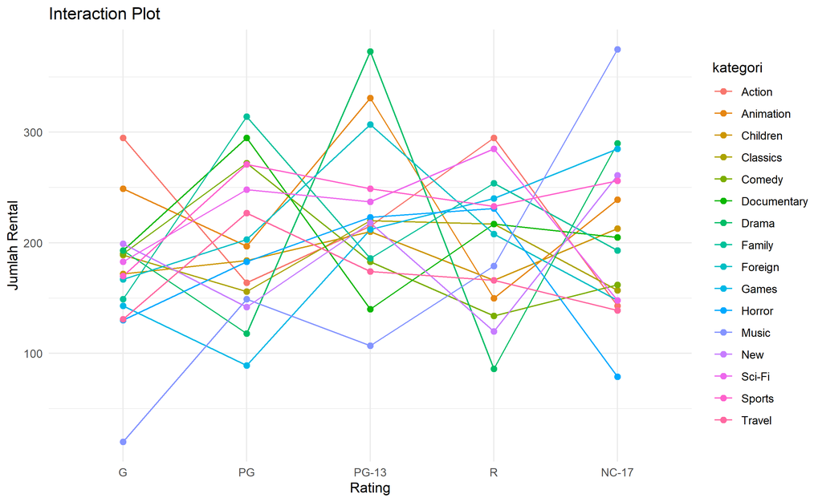

```r
ggplot(
  df_anova,
  aes(
    x = rating,
    y = total_rental,
    group = kategori,
    color = kategori
  )
) +
  geom_line() +
  geom_point(size = 2) +
  theme_minimal() +
  labs(
    title = "Interaction Plot",
    x = "Rating",
    y = "Jumlah Rental"
  )
```

### 7.0.1 Interpretasi Interaction Plot

Interaction plot menunjukkan pola garis antar kategori yang banyak tidak sejajar dan beberapa saling berpotongan. Hal ini mengindikasikan adanya interaksi antara kategori film dan rating terhadap jumlah rental.

Beberapa kategori menunjukkan perubahan jumlah rental yang sangat berbeda pada tiap rating. Misalnya, kategori **Music** memiliki jumlah rental yang sangat rendah pada rating G, namun meningkat tajam pada NC-17 hingga menjadi salah satu yang tertinggi. Sebaliknya, kategori **Drama** mengalami lonjakan besar pada PG-13 tetapi menurun drastis pada rating R.

Kategori seperti **Children** terlihat relatif lebih stabil karena perubahan jumlah rental antar rating tidak terlalu ekstrem dibanding kategori lain.

Pola garis yang saling berpotongan menunjukkan bahwa pengaruh rating terhadap jumlah rental tidak sama pada setiap kategori film. Dengan demikian, popularitas rental film dipengaruhi oleh kombinasi kategori dan rating secara bersamaan, bukan hanya oleh satu faktor secara individual.

# 8 Effect Size

Effect size digunakan untuk mengetahui besarnya pengaruh masing-masing faktor terhadap variansi total rental.

```r
ss <- summary(anova_2way)[[1]][["Sum Sq"]]

ss_total <- sum(ss)

eta_df <- data.frame(
  Faktor = c(
    "Kategori",
    "Rating",
    "Interaksi"
  ),
  Sum_Sq = round(ss,2),
  Eta_Squared = round(ss/ss_total,4)
)

kable(
  eta_df,
  caption = "Effect Size Eta Squared"
) |>
  kable_styling(
    bootstrap_options = c("striped","hover"),
    full_width = FALSE
  )
```

Effect Size Eta Squared

| Faktor | Sum_Sq | Eta_Squared |
| --- | --- | --- |
| Kategori | 38519.80 | 0.1128 |
| Rating | 21207.55 | 0.0621 |
| Interaksi | 281838.45 | 0.8251 |

### 8.0.1 Interpretasi Effect Size

Nilai eta squared ($\eta^2$) menunjukkan proporsi variasi jumlah rental yang dapat dijelaskan oleh masing-masing faktor.

Faktor **interaksi kategori dan rating** memiliki nilai $\eta^2$ terbesar yaitu sebesar 0,8251 atau sekitar 82,51%. Hal ini menunjukkan bahwa kombinasi kategori dan rating film merupakan faktor yang paling dominan dalam menjelaskan variasi jumlah rental pada database Sakila.

Faktor **kategori** memiliki nilai $\eta^2$ sebesar 0,1128 atau sekitar 11,28%, yang menunjukkan bahwa kategori film secara individual juga memberikan pengaruh terhadap jumlah rental meskipun tidak sebesar efek interaksi.

Sementara itu, faktor **rating** memiliki nilai $\eta^2$ sebesar 0,0621 atau sekitar 6,21%, yang berarti rating film memberikan pengaruh paling kecil dibanding faktor lainnya.

# 9 Kesimpulan

Interaction plot menunjukkan adanya pola garis yang tidak sejajar, yang mengindikasikan bahwa pengaruh rating terhadap jumlah rental berbeda pada tiap kategori film.

Analisis effect size menggunakan eta squared menunjukkan faktor yang paling dominan dalam menjelaskan variasi jumlah rental pada database Sakila.